# sup_sales_ab

|  | Invoice ID | Branch | City | Customer type | Gender | Product line | Unit price | Quantity | Tax 5% | Total | Date | Time | Payment | cogs | gross margin percentage | gross income | Rating |
| --- | --- | --- | --- | --- | --- | --- | --- | --- | --- | --- | --- | --- | --- | --- | --- | --- | --- |
| 0 | 750-67-8428 | A | Yangon | Member | Female | Health and beauty | 74.69 | 7 | 26.1415 | 548.9715 | 1/5/2019 | 13:08 | Ewallet | 522.83 | 4.761905 | 26.1415 | 9.1 |
| 1 | 226-31-3081 | C | Naypyitaw | Normal | Female | Electronic accessories | 15.28 | 5 | 3.8200 | 80.2200 | 3/8/2019 | 10:29 | Cash | 76.40 | 4.761905 | 3.8200 | 9.6 |
| 2 | 631-41-3108 | A | Yangon | Normal | Male | Home and lifestyle | 46.33 | 7 | 16.2155 | 340.5255 | 3/3/2019 | 13:23 | Credit card | 324.31 | 4.761905 | 16.2155 | 7.4 |
| 3 | 123-19-1176 | A | Yangon | Member | Male | Health and beauty | 58.22 | 8 | 23.2880 | 489.0480 | 1/27/2019 | 20:33 | Ewallet | 465.76 | 4.761905 | 23.2880 | 8.4 |
| 4 | 373-73-7910 | A | Yangon | Normal | Male | Sports and travel | 86.31 | 7 | 30.2085 | 634.3785 | 2/8/2019 | 10:37 | Ewallet | 604.17 | 4.761905 | 30.2085 | 5.3 |
| ... | ... | ... | ... | ... | ... | ... | ... | ... | ... | ... | ... | ... | ... | ... | ... | ... | ... |
| 995 | 233-67-5758 | C | Naypyitaw | Normal | Male | Health and beauty | 40.35 | 1 | 2.0175 | 42.3675 | 1/29/2019 | 13:46 | Ewallet | 40.35 | 4.761905 | 2.0175 | 6.2 |
| 996 | 303-96-2227 | B | Mandalay | Normal | Female | Home and lifestyle | 97.38 | 10 | 48.6900 | 1022.4900 | 3/2/2019 | 17:16 | Ewallet | 973.80 | 4.761905 | 48.6900 | 4.4 |
| 997 | 727-02-1313 | A | Yangon | Member | Male | Food and beverages | 31.84 | 1 | 1.5920 | 33.4320 | 2/9/2019 | 13:22 | Cash | 31.84 | 4.761905 | 1.5920 | 7.7 |
| 998 | 347-56-2442 | A | Yangon | Normal | Male | Home and lifestyle | 65.82 | 1 | 3.2910 | 69.1110 | 2/22/2019 | 15:33 | Cash | 65.82 | 4.761905 | 3.2910 | 4.1 |
| 999 | 849-09-3807 | A | Yangon | Member | Female | Fashion accessories | 88.34 | 7 | 30.9190 | 649.2990 | 2/18/2019 | 13:28 | Cash | 618.38 | 4.761905 | 30.9190 | 6.6 |

1000 rows × 17 columns

```
Количество уникальных значений в столбце gross margin percentage: 1
```

Датасет представляет собой записи о продажах в супермаркете. Ниже список столбцов:

[output not shown]

```
<class 'pandas.core.frame.DataFrame'>
RangeIndex: 1000 entries, 0 to 999
Data columns (total 17 columns):
 #   Column                   Non-Null Count  Dtype
---  ------                   --------------  -----
 0   Invoice ID               1000 non-null   object
 1   Branch                   1000 non-null   object
 2   City                     1000 non-null   object
 3   Customer type            1000 non-null   object
 4   Gender                   1000 non-null   object
 5   Product line             1000 non-null   object
 6   Unit price               1000 non-null   float64
 7   Quantity                 1000 non-null   int64
 8   Tax 5%                   1000 non-null   float64
 9   Total                    1000 non-null   float64
 10  Date                     1000 non-null   object
 11  Time                     1000 non-null   object
 12  Payment                  1000 non-null   object
 13  cogs                     1000 non-null   float64
 14  gross margin percentage  1000 non-null   float64
 15  gross income             1000 non-null   float64
 16  Rating                   1000 non-null   float64
dtypes: float64(7), int64(1), object(9)
memory usage: 132.9+ KB
```

```
<class 'pandas.core.frame.DataFrame'>
RangeIndex: 1000 entries, 0 to 999
Data columns (total 17 columns):
 #   Column                   Non-Null Count  Dtype
---  ------                   --------------  -----
 0   Invoice ID               1000 non-null   string
 1   Branch                   1000 non-null   category
 2   City                     1000 non-null   category
 3   Customer type            1000 non-null   category
 4   Gender                   1000 non-null   category
 5   Product line             1000 non-null   category
 6   Unit price               1000 non-null   float64
 7   Quantity                 1000 non-null   int32
 8   Tax 5%                   1000 non-null   float64
 9   Total                    1000 non-null   float64
 10  Date                     1000 non-null   datetime64[ns]
 11  Time                     1000 non-null   object
 12  Payment                  1000 non-null   category
 13  cogs                     1000 non-null   float64
 14  gross margin percentage  1000 non-null   float64
 15  gross income             1000 non-null   float64
 16  Rating                   1000 non-null   float64
dtypes: category(6), datetime64[ns](1), float64(7), int32(1), object(1), string(1)
memory usage: 88.9+ KB
```

|  | Unit price | Quantity | Tax 5% | Total | Date | cogs | gross margin percentage | gross income | Rating |
| --- | --- | --- | --- | --- | --- | --- | --- | --- | --- |
| count | 1000.000000 | 1000.000000 | 1000.000000 | 1000.000000 | 1000 | 1000.00000 | 1.000000e+03 | 1000.000000 | 1000.00000 |
| mean | 55.672130 | 5.510000 | 15.379369 | 322.966749 | 2019-02-14 00:05:45.600000 | 307.58738 | 4.761905e+00 | 15.379369 | 6.97270 |
| min | 10.080000 | 1.000000 | 0.508500 | 10.678500 | 2019-01-01 00:00:00 | 10.17000 | 4.761905e+00 | 0.508500 | 4.00000 |
| 25% | 32.875000 | 3.000000 | 5.924875 | 124.422375 | 2019-01-24 00:00:00 | 118.49750 | 4.761905e+00 | 5.924875 | 5.50000 |
| 50% | 55.230000 | 5.000000 | 12.088000 | 253.848000 | 2019-02-13 00:00:00 | 241.76000 | 4.761905e+00 | 12.088000 | 7.00000 |
| 75% | 77.935000 | 8.000000 | 22.445250 | 471.350250 | 2019-03-08 00:00:00 | 448.90500 | 4.761905e+00 | 22.445250 | 8.50000 |
| max | 99.960000 | 10.000000 | 49.650000 | 1042.650000 | 2019-03-30 00:00:00 | 993.00000 | 4.761905e+00 | 49.650000 | 10.00000 |
| std | 26.494628 | 2.923431 | 11.708825 | 245.885335 | NaN | 234.17651 | 6.131498e-14 | 11.708825 | 1.71858 |

```
253.848
```

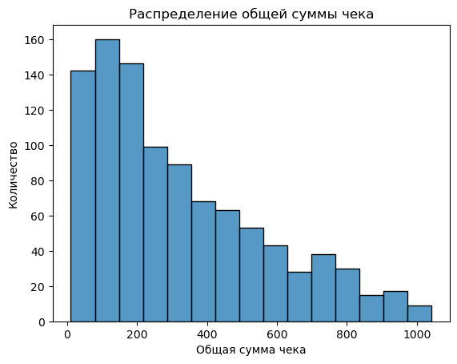

#### Вероятно, мы видим логнормальное распределение, которое типично для данных о сумме покупок

#### Проверим, так ли это

```
Статистика: 0.05610475967542117, p-значение: 0.0035429810604697878
```

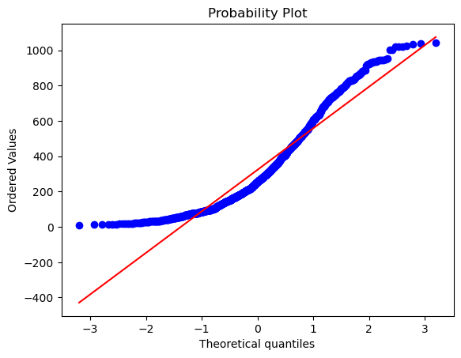

#### Посмотрим как выглядят данные столбца Total, когда мы логарифмируем его

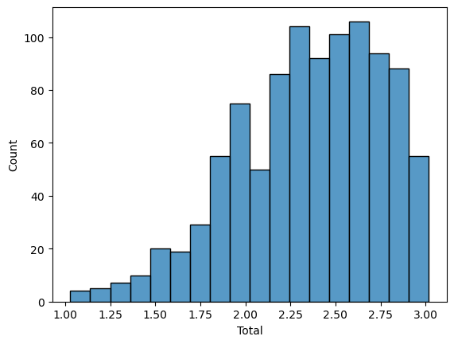

#### Отклоняем гипотезу о том, что данные логнормально распределены.

##### *так же можно преобразовать с помощью boxcox (это расширенное лог преобразование с дополнительным коэффициентом). Я это отдельно сделал, p-значение оказалось равно 0.055, но в данном мини-кейсе я буду работать с не трансформированными данными.

#### Теперь, проводя a/b тестирование мы будем использовать непараметрические тесты, так как параметрические тесты могут справиться хуже (хотя из-за относительно большого размера выборки, результаты могут быть примерно одинаковы)

#### Проведем имитацию A/B теста, выделим 500 случайных строк для выборок A и B

#### Выборка A будет контрольной группой, в которой значения "как было", а выборка B - тестовая, которая получает улучшения и мы будем ожидать статистически значимые увеличения в статистиках столбца "Total".

##### *Я подобрал random_state так, чтобы разница была более велика

```
Среднее значение для выборки A: 309.334053
Среднее значение для выборки B: 336.599445

Стандартное отклонение для выборки A: 242.22261157914662
Стандартное отклонение для выборки B: 248.990197201507

Медиана для выборки A: 236.2815
Медиана для выборки B: 268.96275
```

```
Разница средних значений выборок: -27.26539200000002

Разница медиан выборок: -32.681250000000034
```

#### Я создал специальный класс, который можно найти в этой же папке под именем ab_test_methods.py (в docstring класса доступно описание)

#### Используя его, я буду проводить тест Манна-Уитни, Bootstrap и перестановочный тест

#### Будем использовать уровень значимости равный 0.05

## Критерий Манна-Уитни

##### Используется для сравнения двух независимых выборок и определения, есть ли статистически значимая разница между ними (сравнивает ранги значений)

```
MannwhitneyuResult(statistic=115941.5, pvalue=0.02365485954411995)
```

#### Критерий Манна-Уитни показывает p<0.05, на основе чего можно сказать, что статистически выборка A имеет меньшие значения относительно выборки B (с точки зрения рангов)

## Bootstrap

##### Bootstrap для разниц средних значений выборок

```
Верхняя граница 95% доверительного интервала разницы mean значений: -1.4164374000000015
Для подтверждения альтернативной гипотезы, что mean(B) > mean(A), верхняя граница должна быть ниже нуля
```

```
-1.4164374000000015
```

##### Bootstrap для разниц медиан выборок

```
Верхняя граница 95% доверительного интервала разницы median значений: 3.0505125000000013
Для подтверждения альтернативной гипотезы, что median(B) > median(A), верхняя граница должна быть ниже нуля
```

```
3.0505125000000013
```

#### Верхняя граница 95% доверительного интервала разницы средних значений ниже нуля, соответственно, для этого случая H0 отвергается. Верхняя граница разницы медиан - выше, H0 не отвергается.

## Перестановочный тест

##### Перестановочный тест для средних значений

```
p-значение для разниц mean значений выборок: 0.04123333333333333
Если p-значение меньше заданного ур. значимости, мы принимаем альтернативную гипотезу о том, что mean(B) > mean(A)
```

##### Перестановочный тест для медиан

```
p-значение для разниц median значений выборок: 0.0745
Если p-значение меньше заданного ур. значимости, мы принимаем альтернативную гипотезу о том, что median(B) > median(A)
```

#### p-значение для разниц средних значений меньше заданного уровня значимости, соответственно, мы принимаем альтернативную гипотезу

#### p-значение для разниц медиан больше уровня значимости, в этом случае нельзя отклонить нулевую гипотезу

##### На графике оценки плотности (оцениваент вероятность в каждом интервале на основе данных) можно посмотреть плотности вероятностей значений наших выборок

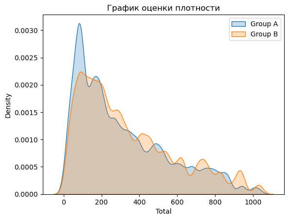

#### По графику оценки плотности мы видим, что в выборке B данные больше представлены для бОльших значений, чем в выборке A.

#### Я проверил как распределены различные столбцы для обеих выборок, столбец с количеством товаров в чеке показал интересные результаты:

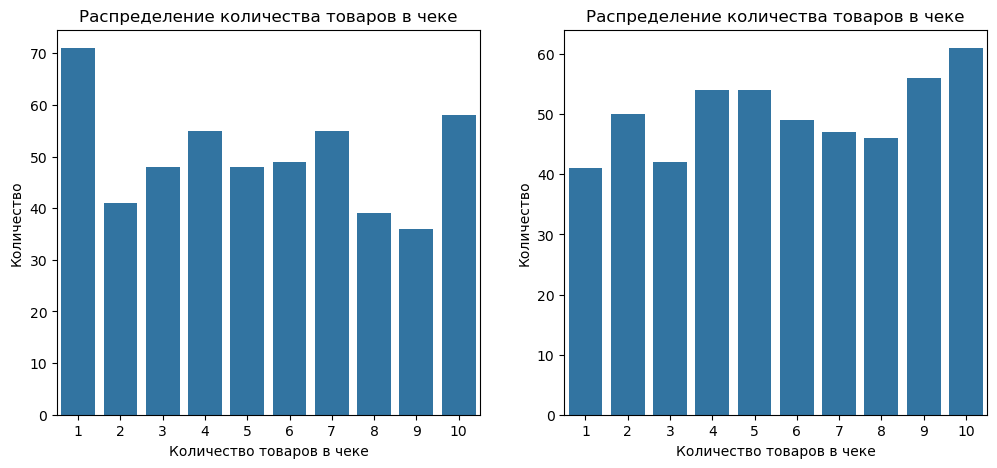

##### Из распределения количества товаров в чеке становится понятно, почему в выборке B среднее и медиана больше, чем в выборке A:

```
- в выборке A самое часто встречающееся количество товаров в чеке это 1
- в выборке B самое часто встречающееся количество товаров в чеке это 10
```

#### Таким образом:

##### - Тест Манна-Уитни показал статистически значимое различие (с установленным нами уровнем значимости в 0.05) в выборках

##### - Bootstrap и перестановочный тест для разниц средних значений отвергают нулевую гипотезу, а для медиан - нет

#### Вероятно, Bootstrap'у и перестановочному тесту не хватает мощности (которая зависит от размера выборки и стандартного отклонения).

#### Посмотрим, при каких разницах в среднем значении и медиане, мощность будет приблизительно равна 0.8 (при не изменении остальных параметров)

```
Мощность теста при разнице средних значений выборок равной 38: 0.805
CPU times: total: 1min 19s
Wall time: 1min 19s
```

```
Мощность теста при разнице медиан выборок равной 57:  0.832
CPU times: total: 2min 58s
Wall time: 2min 58s
```

#### Как видим, более высокая мощность для тестирования разниц медиан достигается с бОльшим трудом. В 80% тестов интервал указывает на отличие в нужную сторону (в пользу альтернативной гипотезы), лишь при разнице медиан в 57. Для средних значений для этого требуется разница в 38.

#### Мощность тестов, где разница средних/медиан соответствует реальной разнице (-27 для средних и -32 для медиан), не достигает 80%, что означает недостаточную мощность. Поэтому следует увеличить объем выборки, чтоб результату было можно доверять с большей уверенностью.

### Низкая мощность означает, что результаты нестабильны и при повторных экспериментах можно получить и незначимый результат. Таким образом, наблюдаемое статистически значимое различие может быть как правдивым сигналом, так и ложным срабатыванием, обусловленным особенностями распределения

### Вычисление необходимого размера выборки для мощности 0.8

```
1004.2211555115606
```

#### То есть для проведения A/B тестирования нам нужно примерно 1000 пользователей в группе A и столько же в группе B

## Размер эффекта по Клиффу

```
0.072468
```

##### Получившийся размер эффекта говорит о том, что вероятность того, что случайно выбранное значение из группы B окажется больше случайно выбранного значения из группы A, примерно на 7 процентных пунктов выше, чем вероятность противоположного исхода

## Байесовский анализ

```
Initializing NUTS using jitter+adapt_diag...
Multiprocess sampling (4 chains in 4 jobs)
NUTS: [mu_A, mu_B, sigma_A, sigma_B]
```

```
Output()
```

```
Sampling 4 chains for 3_000 tune and 6_000 draw iterations (12_000 + 24_000 draws total) took 35 seconds.
```

```
CPU times: total: 9.55 s
Wall time: 42.4 s
```

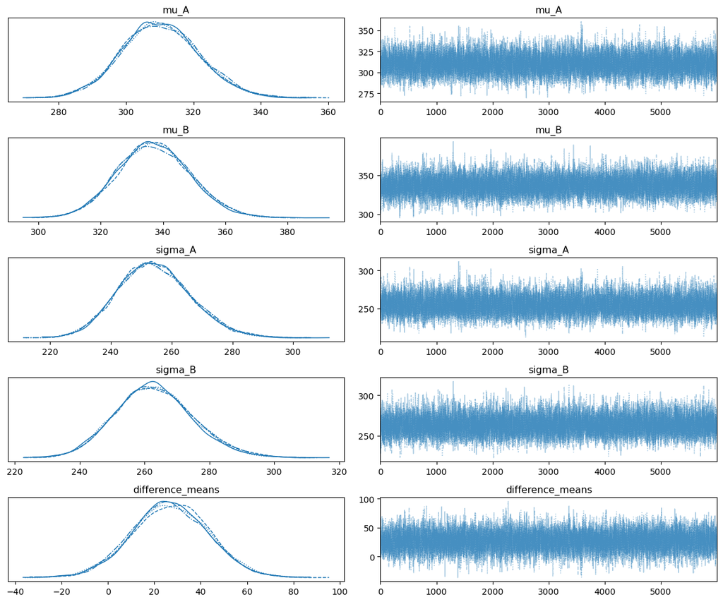

```
Вероятность того, что среднее B больше среднего A: 0.947
Средний прирост (B - A): 26.888
95% HDI: [-5.172, 59.461]
```

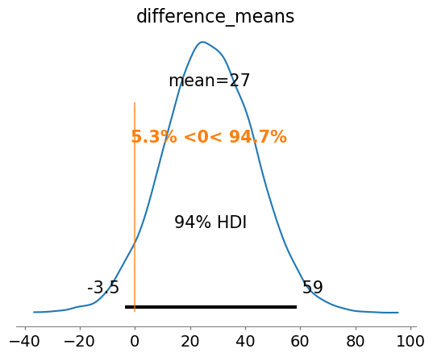

|  | mean | sd | hdi_3% | hdi_97% | mcse_mean | mcse_sd | ess_bulk | ess_tail | r_hat |
| --- | --- | --- | --- | --- | --- | --- | --- | --- | --- |
| mu_A | 310.291 | 11.531 | 289.355 | 332.729 | 0.111 | 0.079 | 10807.0 | 12634.0 | 1.0 |
| mu_B | 337.179 | 11.764 | 314.739 | 358.873 | 0.113 | 0.080 | 10869.0 | 12088.0 | 1.0 |
| sigma_A | 254.457 | 12.013 | 233.162 | 277.993 | 0.116 | 0.082 | 10923.0 | 12908.0 | 1.0 |
| sigma_B | 263.141 | 11.973 | 240.527 | 285.342 | 0.117 | 0.083 | 10546.0 | 11068.0 | 1.0 |
| difference_means | 26.888 | 16.570 | -3.493 | 58.642 | 0.159 | 0.113 | 10810.0 | 12028.0 | 1.0 |

##### Апостериорное распределение разницы средних значений между группами B и A показывает, что средняя разница оценивается в 26.888. Хотя большая часть вероятности (94.7%) сосредоточена в области положительных значений разницы (что указывает на более высокое среднее в группе B), важно отметить, что 94% HDI включает отрицательные значения.

##### Это означает, что, несмотря на наблюдаемую разницу в выборочных средних, данные не предоставляют убедительных доказательств в пользу того, что средние значения группы B больше таковых для группы A.

## Выводы:

#### - Тесты (кроме разниц медиан и байесовского анализа) показывают, что значения выборки B больше значений A

#### - На самом деле, так как мы брали выборку из одного общего распределения, тесты для разниц медиан и байесовский анализ показали верные результаты, а остальные совершили ошибку false positive

#### - В реальной практике нужно было бы проверить, что мы не ухудшаем другие метрики, соответственно их тоже нужно было бы протестировать для групп A и B

#### - Полученным результатам с трудом можно доверять из-за недостаточной мощности тестов (которая показывает, что результаты нестабильны)

#### - В реальности в таком случае я бы рекомендовал вносить изменения, если внедрение улучшений (выборка B) является относительно не затратным. Или продолжать тестирование, используя метод многорукого бандита или байесовский анализ

#### - Стоит помнить, что это имитация A/B теста. В реальности на его проведение влияют время сбора данных, сезонность, случайность выбора и прочие факторы